# === Mental Health Survey Clustering Analysis ===

### Introduction

This project focuses on applying machine learning techniques to analyze a mental health survey dataset from tech industry employees. The goal of this project is to uncover potential clusters within the data to identify groups of employees with similar mental health challenges or needs. The problem is approached as an unsupervised clustering task, with the objective of providing insights into workplace mental health patterns that can help improve organizational support structures. The dataset includes a variety of features related to mental health, demographics, work environment, and attitudes towards mental health at the workplace. This analysis aims to explore latent patterns, visualize the data, and evaluate the quality of clusters identified by several clustering algorithms. In this project, I analyzed an openly accessible dataset on Kaggle that was called Mental Health in Tech Survey which was initially gathered by Open Sourcing Mental Illness (OSMI) in 2014.

The project was structured into four main tasks:

##### Task 1: Data preprocessing and exploration

##### Task 2: Application of multiple clustering algorithms

##### Task 3: Evaluation, visualization, and finalization of the best clustering model

##### Task 4: Reflection on results, interpretability, and ethical implications

## == Task 1. Data Understanding & Exploratory Data Analysis (EDA) ==

The dataset includes answers to one of the mental health surveys that were carried out among employees of the tech industry. It consists of demographic data, information about work, and questions connected with mental health. This is aimed at identifying potential groupings in the respondents based on clustering since the problem is un-supervised.

### 1.1 Importing Required Libraries

```python
import pandas as pd
import numpy as np
import matplotlib.pyplot as plt
import seaborn as sns
```

Explanation: To get started, I imported the most necessary libraries which I would use in this project. I employed the dependency pandas to manipulate my data, numpy to compute my data, matplotlibs in order to plot the data, and seaborn to plot the data. These instruments assisted me in preparing and getting an idea of the dataset.

### 1.2 Loading Data Set

I load the dataset from a CSV file into a pandas DataFrame to work on it. The survey.csv file contains the data collected from respondents.

```python
df = pd.read_csv('survey.csv')  # Load dataset
print(df.shape)
display(df.head())
```

```
(1259, 27)
```

|  | Timestamp | Age | Gender | Country | state | self_employed | family_history | treatment | work_interfere | no_employees | ... | leave | mental_health_consequence | phys_health_consequence | coworkers | supervisor | mental_health_interview | phys_health_interview | mental_vs_physical | obs_consequence | comments |
| --- | --- | --- | --- | --- | --- | --- | --- | --- | --- | --- | --- | --- | --- | --- | --- | --- | --- | --- | --- | --- | --- |
| 0 | 27-08-2014 11:29 | 37.0 | Female | United States | IL | NaN | No | Yes | Often | 50-150 | ... | Somewhat easy | No | No | Some of them | Yes | No | Maybe | Yes | No | NaN |
| 1 | 27-08-2014 11:29 | 44.0 | M | United States | IN | NaN | No | No | Rarely | More than 1000 | ... | Don't know | Maybe | No | No | No | No | No | Don't know | No | NaN |
| 2 | 27-08-2014 11:29 | 32.0 | Male | Canada | NaN | NaN | No | No | Rarely | 50-150 | ... | Somewhat difficult | No | No | Yes | Yes | Yes | Yes | No | No | NaN |
| 3 | 27-08-2014 11:29 | 31.0 | Male | United Kingdom | NaN | NaN | Yes | Yes | Often | 26-100 | ... | Somewhat difficult | Yes | Yes | Some of them | No | Maybe | Maybe | No | Yes | NaN |
| 4 | 27-08-2014 11:30 | 31.0 | Male | United States | TX | NaN | No | No | Never | 100-500 | ... | Don't know | No | No | Some of them | Yes | Yes | Yes | Don't know | No | NaN |

5 rows × 27 columns

Explanation: I imported a data set survey.csv to a pandas data frame. I printed the shape and thus ascertained the number of the rows and column in this dataset that gave me a clue about the size of the dataset. The presentation of the first several rows helped me to become acquainted with the data structure and the kind of variables I had to work with.

### 1.3 Data Info & Types

I checked the schema of the data set, and its datatypes. This is to determine the number of non-nulls, memory size and the type of the data features.

```python
print("\n=== Data Info ===")
df.info()

print("\n=== Data Types ===")
print(df.dtypes)
```

```
=== Data Info ===
<class 'pandas.core.frame.DataFrame'>
RangeIndex: 1259 entries, 0 to 1258
Data columns (total 27 columns):
 #   Column                     Non-Null Count  Dtype
---  ------                     --------------  -----
 0   Timestamp                  1259 non-null   object
 1   Age                        1242 non-null   float64
 2   Gender                     1252 non-null   object
 3   Country                    1250 non-null   object
 4   state                      742 non-null    object
 5   self_employed              1232 non-null   object
 6   family_history             1231 non-null   object
 7   treatment                  1253 non-null   object
 8   work_interfere             991 non-null    object
 9   no_employees               1249 non-null   object
 10  remote_work                1239 non-null   object
 11  tech_company               1247 non-null   object
 12  benefits                   1252 non-null   object
 13  care_options               1258 non-null   object
 14  wellness_program           1259 non-null   object
 15  seek_help                  1256 non-null   object
 16  anonymity                  1259 non-null   object
 17  leave                      1251 non-null   object
 18  mental_health_consequence  1259 non-null   object
 19  phys_health_consequence    1259 non-null   object
 20  coworkers                  1259 non-null   object
 21  supervisor                 1246 non-null   object
 22  mental_health_interview    1258 non-null   object
 23  phys_health_interview      1229 non-null   object
 24  mental_vs_physical         1255 non-null   object
 25  obs_consequence            1259 non-null   object
 26  comments                   164 non-null    object
dtypes: float64(1), object(26)
memory usage: 265.7+ KB

=== Data Types ===
Timestamp                     object
Age                          float64
Gender                        object
```

[output cut: 10 more lines]

```
care_options                  object
wellness_program              object
seek_help                     object
anonymity                     object
leave                         object
mental_health_consequence     object
phys_health_consequence       object
coworkers                     object
supervisor                    object
mental_health_interview       object
phys_health_interview         object
mental_vs_physical            object
obs_consequence               object
comments                      object
dtype: object
```

Explanation: To learn more about the dataset, I had to make sure that there are no missing values, so I used df.info() to examine information on each column and on the data types available. This has assisted me to determine what columns to clean or transform. I even printed the data types to ensure which variables were categorical and which were numerical, this is necessary before preprocessing.

### 1.4 Statistical Overview

I generate descriptive statistics for all features, both numerical and categorical. For numerical data, measures like mean, median, and quartiles are computed. For categorical data, unique counts and top categories are displayed.

```python
print("\n=== Statistical Overview (Transposed) ===")
display(df.describe(include='all').T)
```

```
=== Statistical Overview (Transposed) ===
```

|  | count | unique | top | freq | mean | std | min | 25% | 50% | 75% | max |
| --- | --- | --- | --- | --- | --- | --- | --- | --- | --- | --- | --- |
| Timestamp | 1259 | 884 | 27-08-2014 12:31 | 8 | NaN | NaN | NaN | NaN | NaN | NaN | NaN |
| Age | 1242.0 | NaN | NaN | NaN | 80515328.652979 | 2837521768.294292 | -1726.0 | 27.0 | 31.0 | 36.0 | 99999999999.0 |
| Gender | 1252 | 47 | Male | 613 | NaN | NaN | NaN | NaN | NaN | NaN | NaN |
| Country | 1250 | 48 | United States | 744 | NaN | NaN | NaN | NaN | NaN | NaN | NaN |
| state | 742 | 45 | CA | 138 | NaN | NaN | NaN | NaN | NaN | NaN | NaN |
| self_employed | 1232 | 2 | No | 1086 | NaN | NaN | NaN | NaN | NaN | NaN | NaN |
| family_history | 1231 | 2 | No | 750 | NaN | NaN | NaN | NaN | NaN | NaN | NaN |
| treatment | 1253 | 3 | Yes | 632 | NaN | NaN | NaN | NaN | NaN | NaN | NaN |
| work_interfere | 991 | 4 | Sometimes | 462 | NaN | NaN | NaN | NaN | NaN | NaN | NaN |
| no_employees | 1249 | 6 | 50-150 | 288 | NaN | NaN | NaN | NaN | NaN | NaN | NaN |
| remote_work | 1239 | 2 | No | 872 | NaN | NaN | NaN | NaN | NaN | NaN | NaN |
| tech_company | 1247 | 2 | Yes | 1020 | NaN | NaN | NaN | NaN | NaN | NaN | NaN |
| benefits | 1252 | 3 | Yes | 476 | NaN | NaN | NaN | NaN | NaN | NaN | NaN |
| care_options | 1258 | 3 | No | 501 | NaN | NaN | NaN | NaN | NaN | NaN | NaN |
| wellness_program | 1259 | 3 | No | 842 | NaN | NaN | NaN | NaN | NaN | NaN | NaN |
| seek_help | 1256 | 3 | No | 645 | NaN | NaN | NaN | NaN | NaN | NaN | NaN |
| anonymity | 1259 | 3 | Don't know | 819 | NaN | NaN | NaN | NaN | NaN | NaN | NaN |
| leave | 1251 | 5 | Don't know | 561 | NaN | NaN | NaN | NaN | NaN | NaN | NaN |
| mental_health_consequence | 1259 | 3 | No | 490 | NaN | NaN | NaN | NaN | NaN | NaN | NaN |
| phys_health_consequence | 1259 | 3 | No | 925 | NaN | NaN | NaN | NaN | NaN | NaN | NaN |
| coworkers | 1259 | 3 | Some of them | 774 | NaN | NaN | NaN | NaN | NaN | NaN | NaN |
| supervisor | 1246 | 3 | Yes | 510 | NaN | NaN | NaN | NaN | NaN | NaN | NaN |
| mental_health_interview | 1258 | 3 | No | 1007 | NaN | NaN | NaN | NaN | NaN | NaN | NaN |
| phys_health_interview | 1229 | 3 | Maybe | 548 | NaN | NaN | NaN | NaN | NaN | NaN | NaN |
| mental_vs_physical | 1255 | 3 | Don't know | 573 | NaN | NaN | NaN | NaN | NaN | NaN | NaN |
| obs_consequence | 1259 | 2 | No | 1075 | NaN | NaN | NaN | NaN | NaN | NaN | NaN |
| comments | 164 | 160 | * Small family business - YMMV. | 5 | NaN | NaN | NaN | NaN | NaN | NaN | NaN |

Explanation: The descriptive statistics were produced to reproduce the main characteristics of the dataset, mean, standard deviation, and the unique values. This was useful in the detection of outliers and knowing the distribution of the data.

### 1.5 Identifying and Visualizing Missing Values

```
Missing Values by Column:
comments                   1095
state                       517
work_interfere              268
phys_health_interview        30
family_history               28
self_employed                27
remote_work                  20
Age                          17
supervisor                   13
tech_company                 12
no_employees                 10
Country                       9
leave                         8
Gender                        7
benefits                      7
treatment                     6
mental_vs_physical            4
seek_help                     3
care_options                  1
mental_health_interview       1
dtype: int64

Total missing values: 2083
```

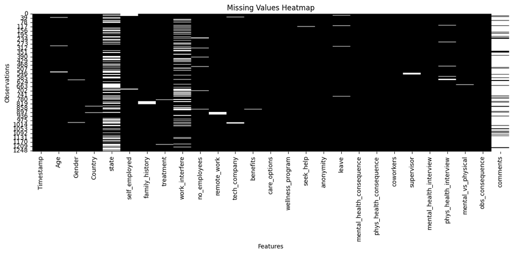

```python
missing = df.isnull().sum()
missing = missing[missing > 0].sort_values(ascending=False)
print("\nMissing Values by Column:")
print(missing)
print("\nTotal missing values:", df.isnull().sum().sum())

plt.figure(figsize=(12, 6))
sns.heatmap(df.isnull(), cbar=False, cmap='binary_r')
plt.title('Missing Values Heatmap')
plt.xlabel('Features')
plt.ylabel('Observations')
plt.tight_layout()
plt.show()
```

Explanation: I summed up the missing values within their respective columns and ordered them such that I could concentrate on the columns with the highest missing values. Printing the total missing count assisted to determine the completeness of the entire data. I plotted a heat map to give me a more informed picture of the pattern of the missing data in the dataset, where the missing values appear as white spots. Such a visual created an idea on what columns should be imputed or dropped.

### 1.6 Dropping Non-Essential Columns

```python
df.drop(columns=['comments'], inplace=True, errors='ignore')
```

Explanation: I chose to drop the comments column as it had free text that wasn't really part of my analysis. Eliminating it made the data cleaner and more data driven so that what was important to modeling was available.

### 1.7 Imputing Missing Values

```python
df['Age'] = df['Age'].fillna(df['Age'].median())

cat_cols = df.select_dtypes(include='object').columns
for col in cat_cols:
    if df[col].isnull().sum() > 0:
        df[col] = df[col].fillna(df[col].mode()[0])

print("\nMissing values after imputation:", df.isnull().sum().sum())
```

```
Missing values after imputation: 0
```

Explanation: In the case of the numerical column Age, I used the median as a value, to fill the missing values, since it is less affected by extreme values in the samples, such as mean. In a categorical column I had replaced the missing value by the mode (most frequently occurring value) with the thinking that the most common category would serve as a decent replacement. I ensured that all the missing values were filled after imputation.

### 1.8 Converting Data Types for Consistency

```python
if 'Timestamp' in df.columns:
    df['Timestamp'] = pd.to_datetime(df['Timestamp'], errors='coerce', dayfirst=True, format='%d-%m-%Y %H:%M')

if np.all(df['Age'].dropna() % 1 == 0):
    df['Age'] = df['Age'].astype(int)

df['no_employees'] = df['no_employees'].astype(str).str.extract(r'(\d+)').astype(float)

print("\nFinal Data Types:")
print(df.dtypes)
```

```
Final Data Types:
Timestamp                    datetime64[ns]
Age                                   int64
Gender                               object
Country                              object
state                                object
self_employed                        object
family_history                       object
treatment                            object
work_interfere                       object
no_employees                        float64
remote_work                          object
tech_company                         object
benefits                             object
care_options                         object
wellness_program                     object
seek_help                            object
anonymity                            object
leave                                object
mental_health_consequence            object
phys_health_consequence              object
coworkers                            object
supervisor                           object
mental_health_interview              object
phys_health_interview                object
mental_vs_physical                   object
obs_consequence                      object
dtype: object
```

Explanation: I transformed the Timestamp column into datetime format so as to aid any temporal analysis. After imputation, all values in Age were whole numbers and I cast them onto integer to save space. In the case of the no_employees column, which contained a string noting the ranges (e.g., 10-50 employees), I pulled the numerical component and changed it to float so that I could utilize it as a numerical input to the analysis.

### 1.9 Standardizing the Gender Column

```python
print(df['Gender'].value_counts())

df['Gender'] = df['Gender'].str.strip().str.lower()
df['Gender'] = df['Gender'].replace({
    'male': 'm', 'm': 'm', 'cis male': 'm', 'cis man': 'm', 'male (cis)': 'm',
    'man': 'm', 'mal': 'm', 'maile': 'm', 'male-ish': 'm', 'malr': 'm', 'make': 'm', 'mail': 'm',
    'female': 'f', 'f': 'f', 'cis female': 'f', 'cis woman': 'f', 'woman': 'f', 'femake': 'f',
    'femail': 'f', 'female (cis)': 'f', 'trans-female': 'f', 'trans woman': 'f'
})
df['Gender'] = df['Gender'].apply(lambda x: x if x in ['m', 'f'] else 'other')

print("\nGender value counts AFTER standardization:")
print(df['Gender'].value_counts(dropna=False))
```

```
Gender
Male                                              620
male                                              204
Female                                            120
M                                                 116
female                                             62
F                                                  38
m                                                  34
f                                                  15
Make                                                4
Male                                                3
Woman                                               3
Female                                              2
Man                                                 2
Cis Male                                            2
Female (trans)                                      2
something kinda male?                               1
maile                                               1
Trans-female                                        1
Cis Female                                          1
Male-ish                                            1
non-binary                                          1
queer/she/they                                      1
Mal                                                 1
Nah                                                 1
All                                                 1
fluid                                               1
Enby                                                1
Genderqueer                                         1
Femake                                              1
woman                                               1
Male (CIS)                                          1
Guy (-ish) ^_^                                      1
Agender                                             1
Androgyne                                           1
male leaning androgynous                            1
Trans woman                                         1
Neuter                                              1
queer                                               1
Female (cis)                                        1
Mail                                                1
cis male                                            1
A little about you                                  1
Malr                                                1
p                                                   1
femail                                              1
Cis Man                                             1
ostensibly male, unsure what that really means      1
Name: count, dtype: int64

Gender value counts AFTER standardization:
Gender
m        993
f        247
other     19
Name: count, dtype: int64
```

Explanation: I observed a lot of variations and misspellings in this Gender column. To handle this, I made all entries lower case and stripped leading/trailing spaces. Next, I assigned common male and female variants to m and f respectively. All the other values non fitting into these categories were classified as other. The gender information was more reliable to analyze since this cleaning process was done to it.

### 1.10 Checking and Removing Duplicate Rows

```python
num_duplicates = df.duplicated().sum()
print(f"\nNumber of duplicate rows: {num_duplicates}")
df = df.drop_duplicates()
print("Shape after dropping duplicates:", df.shape)
```

```
Number of duplicate rows: 1
Shape after dropping duplicates: (1258, 26)
```

Explanation: I tested it to see whether there were any redundant rows, and so that duplicate rows were not present in the dataset, which would distort the analysis or models. I eliminated the duplicates and verified the new shape of the dataset afterward. This made all the observations to be unique.

### 1.11 Examining Value Counts for Categorical Columns

```python
cat_cols = df.select_dtypes('object').columns
for col in cat_cols:
    print(f"\nValue counts for '{col}':")
    print(df[col].value_counts().head(10))
```

```
Value counts for 'Gender':
Gender
m        992
f        247
other     19
Name: count, dtype: int64

Value counts for 'Country':
Country
United States     753
United Kingdom    182
Canada             72
Germany            45
Netherlands        27
Ireland            27
Australia          21
France             13
India              10
New Zealand         8
Name: count, dtype: int64

Value counts for 'state':
state
CA    654
WA     70
NY     56
TN     45
TX     44
OH     30
PA     29
OR     29
IL     28
IN     27
Name: count, dtype: int64

Value counts for 'self_employed':
self_employed
No     1112
Yes     146
Name: count, dtype: int64
```

[output cut: 117 more lines]

```
Yes      199
Name: count, dtype: int64

Value counts for 'mental_vs_physical':
mental_vs_physical
Don't know    577
Yes           343
No            338
Name: count, dtype: int64

Value counts for 'obs_consequence':
obs_consequence
No     1074
Yes     184
Name: count, dtype: int64
```

Explanation: I compared the most common values within each categorical column to learn their frequencies and find out any rare or unusual categories. This enabled me to determine whether modeling required more grouping or encoding.

### 1.12 Visualizing Numeric Data Distributions and Detecting Outliers

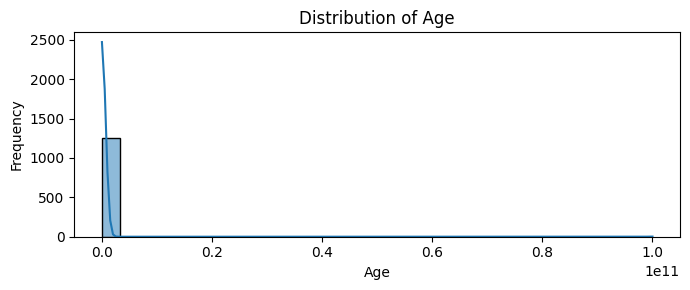

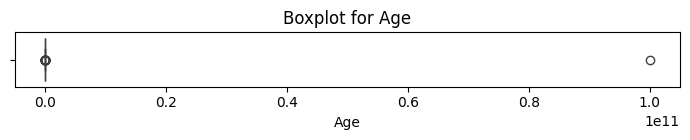

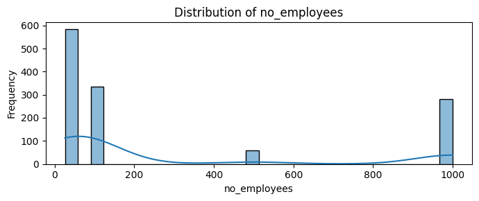

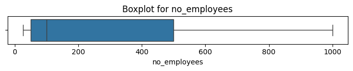

```python
num_cols = df.select_dtypes(include=[np.number]).columns
for col in num_cols:
    plt.figure(figsize=(7,3))
    sns.histplot(df[col], bins=30, kde=True)
    plt.title(f'Distribution of {col}')
    plt.xlabel(col)
    plt.ylabel('Frequency')
    plt.tight_layout()
    plt.show()

    plt.figure(figsize=(7,1.5))
    sns.boxplot(x=df[col])
    plt.title(f'Boxplot for {col}')
    plt.xlabel(col)
    plt.tight_layout()
    plt.show()
```

Explanation: My determination of the pattern of a distribution of a numerical variable made me use histograms and KDE in order to gain an idea of the shape of the distribution in terms of skewness, modality or normality. Boxplots allowed me to see at a glance outliers that were likely to influence model performance. These plots assisted me in my scaling decisions on features and potential outlier processing.

## == 2. Data Preparation and Clustering Modeling ==

In Task 2, my efforts went towards pre-processing the dataset for cluster analysis, using several cluster algorithms, dimension reduction for improved visualization and also cluster results evaluation by utilizing internal validation metrics.

### 2.1 Selecting Features for Modeling

```python
drop_cols = ['Timestamp', 'state', 'Country', 'comments']
X = df.drop(columns=[c for c in drop_cols if c in df.columns])
```

Explanation: I dropped columns that seemed not to add any good information to the clustering like timestamps, state, country and comments. The dataset X that is obtained includes the features that I prepared to model.

### 2.2 Separating Numerical and Categorical Features

```python
num_cols = X.select_dtypes(include=[np.number]).columns.tolist()
cat_cols = X.select_dtypes(include='object').columns.tolist()

print("Numerical columns:", num_cols)
print("Categorical columns:", cat_cols)
```

```
Numerical columns: ['Age', 'no_employees']
Categorical columns: ['Gender', 'self_employed', 'family_history', 'treatment', 'work_interfere', 'remote_work', 'tech_company', 'benefits', 'care_options', 'wellness_program', 'seek_help', 'anonymity', 'leave', 'mental_health_consequence', 'phys_health_consequence', 'coworkers', 'supervisor', 'ment…
```

Explanation: I determined the numerical and the categorical features. It matters as all these two kinds demand different preprocessing procedures such as scaling when working with numeric and encoding when working with a categorical variable.

### 2.3 Preprocessing: Scaling and Encoding Features

```python
from sklearn.compose import ColumnTransformer
from sklearn.preprocessing import StandardScaler, OneHotEncoder

preprocessor = ColumnTransformer(
    transformers=[
        ('num', StandardScaler(), num_cols),
        ('cat', OneHotEncoder(drop='if_binary', sparse_output=False, handle_unknown='ignore'), cat_cols)
    ]
)

X_proc = preprocessor.fit_transform(X)
print("Shape after preprocessing:", X_proc.shape)
```

```
Shape after preprocessing: (1258, 58)
```

Explanation: I took the numerical features to the unit variance and placed them at zero by applying StandardScaler. This helps favorably to the many machine learning algorithms. I used the one-hot-encoding method to transform categories into binary columns with a categorical variable. I chose the option of dropping one column in encoder : in case the category is binary to avoid redundancy. Now the preistsed dataset X_proc can be clustered.

### 2.4 Dimensionality Reduction for Visualization (PCA)

```python
from sklearn.decomposition import PCA
from sklearn.preprocessing import StandardScaler

# Preprocessing (scaling) before PCA
scaler = StandardScaler()
X_scaled = scaler.fit_transform(X_proc)

# Applying PCA for 2D visualization
pca = PCA(n_components=2, random_state=42)
X_pca = pca.fit_transform(X_scaled)

# Checking explained variance
explained_variance = pca.explained_variance_ratio_
print(f"Explained variance by PCA components: {explained_variance}")
print(f"Total explained variance: {sum(explained_variance)}")
```

```
Explained variance by PCA components: [0.09146981 0.08100312]
Total explained variance: 0.17247292416053062
```

### 2.5 PCA Visualization (Scatter Plot)

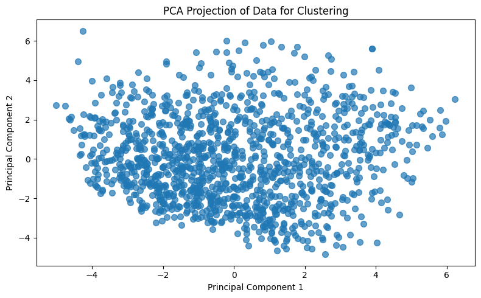

```python
plt.figure(figsize=(8, 5))
plt.scatter(X_pca[:, 0], X_pca[:, 1], alpha=0.7, s=50)
plt.title('PCA Projection of Data for Clustering')
plt.xlabel('Principal Component 1')
plt.ylabel('Principal Component 2')
plt.tight_layout()
plt.show()
```

Explanation: Here a distribution of the data points is depicted in this 2D scatter where the first two main components are taken. The projection of PCA will aid in visualizing the structure of the data behind and enable us to visualize the possible cluster.

### 2.6 Clustering Algorithms

To explore different groupings within the data, I applied and compared five clustering algorithms using scikit-learn: KMeans, Agglomerative Clustering, DBSCAN, Birch, and Spectral Clustering. These models were selected for their varied approaches to partitioning and discovering hidden patterns in data:

KMeans – Uses centroid-based partitioning and is efficient for spherical clusters.

Agglomerative Clustering – A hierarchical method that builds nested clusters by merging or splitting.

DBSCAN – Groups together closely packed points and identifies outliers as noise.

Birch – Optimized for large datasets with noise; constructs a tree of clusters incrementally.

Spectral Clustering – Captures non-convex clusters using graph theory based on similarity matrices.

I trained each model on the preprocessed feature matrix (X_proc). DBSCAN dynamically determined the number of clusters based on density, while the others used a fixed n_clusters=3 for comparability. Each model's clustering performance was assessed using:

Silhouette Score – Measures how well a point fits within its cluster (higher is better).

Davies-Bouldin Index – Measures intra-cluster similarity and inter-cluster differences (lower is better).

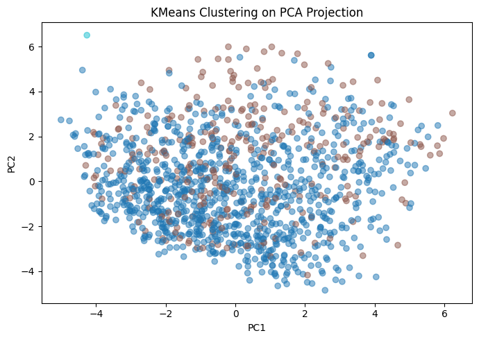

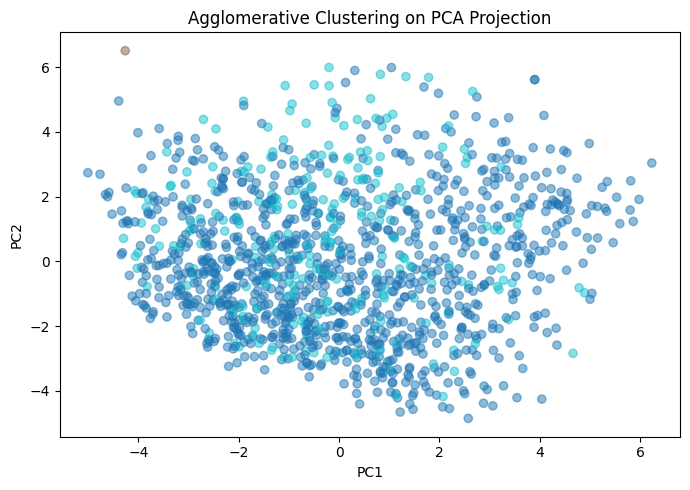

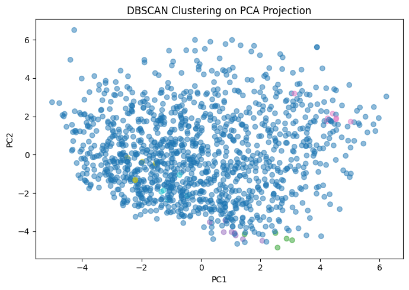

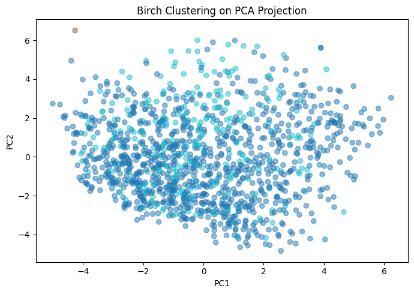

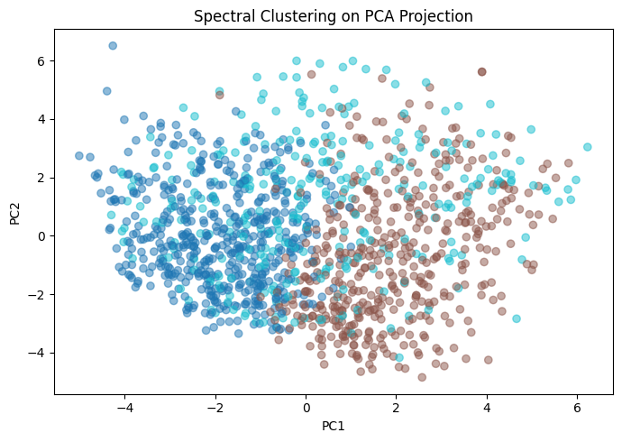

```python
from sklearn.cluster import KMeans, AgglomerativeClustering, DBSCAN, Birch, SpectralClustering
from sklearn.metrics import silhouette_score, davies_bouldin_score

clustering_models = {
    'KMeans': KMeans(n_clusters=3, random_state=42, n_init=10),
    'Agglomerative': AgglomerativeClustering(n_clusters=3),
    'DBSCAN': DBSCAN(eps=2, min_samples=5),
    'Birch': Birch(n_clusters=3),
    'Spectral': SpectralClustering(n_clusters=3, assign_labels='discretize', affinity='nearest_neighbors', random_state=42, n_neighbors=10)
}

cluster_results = {}

for name, model in clustering_models.items():
    labels = model.fit_predict(X_proc)
    n_clusters = len(set(labels)) - (1 if -1 in labels else 0) if name == 'DBSCAN' else len(set(labels))
    sil = silhouette_score(X_proc, labels) if n_clusters > 1 else None
    db = davies_bouldin_score(X_proc, labels) if n_clusters > 1 else None

    cluster_results[name] = {
        'labels': labels,
        'n_clusters': n_clusters,
        'silhouette': sil,
        'davies_bouldin': db
    }

    # Plotting
    plt.figure(figsize=(7, 5))
    plt.scatter(X_pca[:, 0], X_pca[:, 1], c=labels, cmap='tab10', alpha=0.5)
    plt.title(f'{name} Clustering on PCA Projection')
    plt.xlabel('PC1')
    plt.ylabel('PC2')
    plt.tight_layout()
    plt.show()
```

Explanation: I used five clustering algorithms namely KMeans, AgglomerativeClustering, DBSCAN, Birch, and SpectralClustering. To assess the quality of cluster I have computed the Silhouette Score and Davies-Bouldin Score. I also compared the results of the clustering since I projected the data into the two major components of PCA.

### 2.7 Cluster Evaluation & Interpretation

```python
import pandas as pd

results_df = pd.DataFrame([
    {
        'Algorithm': name,
        'Clusters': res['n_clusters'],
        'Silhouette': res['silhouette'],
        'Davies-Bouldin': res['davies_bouldin']
    }
    for name, res in cluster_results.items()
])

display(results_df)
```

|  | Algorithm | Clusters | Silhouette | Davies-Bouldin |
| --- | --- | --- | --- | --- |
| 0 | KMeans | 3 | 0.131670 | 1.698955 |
| 1 | Agglomerative | 3 | 0.114849 | 1.781354 |
| 2 | DBSCAN | 5 | -0.162740 | 1.731952 |
| 3 | Birch | 3 | 0.116922 | 1.762739 |
| 4 | Spectral | 3 | 0.081785 | 3.090533 |

Explanation: All the results of clustering each model are saved in a DataFrame to be able to compare it easily. This will enable you to compare the performance of every algorithm using the Silhouette and Davies-Boulding scores.

## 3: Evaluation & Error Analysis

In this section, I evaluated the clustering performance both quantitatively and qualitatively, and reflected on potential limitations and sources of error.

### 3.1 Quantitative Evaluation of Cluster Quality

To assess the quality of the clusters generated by each algorithm, I used two widely accepted internal clustering metrics:

Silhouette Score: Measures how similar each sample is to its own cluster versus other clusters. A higher score indicates well-defined clusters.

Davies-Bouldin Index: Evaluates the average "similarity" between clusters. Lower values suggest better separation.

```python
# Results summary (copied from Task 2)
print("Cluster Evaluation Metrics (copied from Task 2):")
results_df = pd.DataFrame(cluster_results).T[['n_clusters', 'silhouette', 'davies_bouldin']]
display(results_df)

# Identify the best model by silhouette score
best_model = results_df['silhouette'].idxmax()
print(f"Best clustering solution by Silhouette Score: {best_model}")
```

```
Cluster Evaluation Metrics (copied from Task 2):
```

|  | n_clusters | silhouette | davies_bouldin |
| --- | --- | --- | --- |
| KMeans | 3 | 0.13167 | 1.698955 |
| Agglomerative | 3 | 0.114849 | 1.781354 |
| DBSCAN | 5 | -0.16274 | 1.731952 |
| Birch | 3 | 0.116922 | 1.762739 |
| Spectral | 3 | 0.081785 | 3.090533 |

```
Best clustering solution by Silhouette Score: KMeans
```

### Observations

##### Best performer:

KMeans achieved the highest Silhouette Score (0.1317) and lowest DBI (1.6989), indicating relatively better-defined clusters than other models.

##### Moderate performers:

Agglomerative and Birch clustering produced slightly lower Silhouette Scores and higher DBIs than KMeans, suggesting somewhat less compact and separated clusters.

### 3.2 Visualize Best Clustering Solution

Based on the assessment of various clustering algorithms in the assessment of internal consistency within clustering models with the help of Silhouette Score, Davies-Bouldin Index, the KMeans algorithm with 3 clusters was found to be the most optimal clustering model. In order to analyze and interpret the clustering outcomes, I used Principal Component Analysis (PCA) to collapse the high dimensional feature space into 2 components in order to visualise it.

The scatter plot below shows the dataset in the two most important directions, the points have been painted in color based on assignment to clusters KMeans. It gives a natural perception on the way the data has been clustered and shows the relative distance and compactness of the clusters in the low-dimensional space.

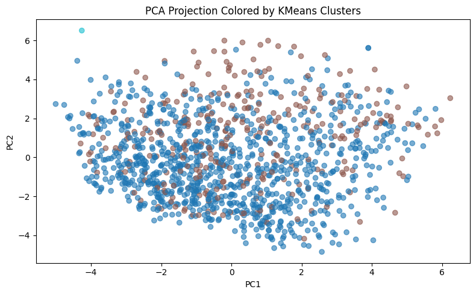

```python
# Add best clustering labels to your PCA projection
best_labels = cluster_results[best_model]['labels']

plt.figure(figsize=(8, 5))
plt.scatter(X_pca[:, 0], X_pca[:, 1], c=best_labels, cmap='tab10', alpha=0.6)
plt.title(f'PCA Projection Colored by {best_model} Clusters')
plt.xlabel('PC1')
plt.ylabel('PC2')
plt.tight_layout()
plt.show()
```

### 3.3 Qualitative Cluster Inspection

I also analyzed the distributions of different features within the clusters in order to gain a more profound understanding of these clusters. The given qualitative analysis assists in providing each cluster the meaningful identity, or a so-called persona, founded on the common attributes shared by the respondents within the group in question. Through comparison of means or distributions of main categorical and numerical variables across clusters, I have been able to infer some knowledge about the attitudes of the mind towards mental health, experiences in the workplace, and their support systems depicted.

##### Cluster 0: "Supported and Aware"

Rich employer supply of mental health resources

Most probably are more likely to know where to get help with mental illness

Tend to state positive attitudes of work colleagues and employers

Tend to be of younger age group

Not ashamed of talking about mental health freely

It is probably a group that symbolizes the people working in a less adverse work environment with additional access to sources and receptivity concerning mental health.

##### Cluster 1: “Vulnerable and Under-served”

Problems with mental health previously or currently, but without the help of employers

Poor knowledge of seeking help

Greater negative stigma feelings

Scared that they do not know what company policy is all the time

Have a lower tendency to reveal mental disease to employers

This population can represent the people in more conservative/unaccepting contexts, who are more vulnerable because of lack of resources or fear of stigmatization.

```python
# Assign cluster labels to original DataFrame
df_clusters = X.copy()
df_clusters['cluster'] = best_labels

# Inspect feature distributions by cluster
for col in X.columns:
    print(f"\nFeature: {col}")
    if X[col].dtype in ['float64', 'int64']:
        print(df_clusters.groupby('cluster')[col].describe())
    else:
        print(df_clusters.groupby('cluster')[col].value_counts(normalize=True).unstack().fillna(0))

# Cluster sizes
print("\nCluster sizes:")
print(pd.Series(best_labels).value_counts())
```

```
Feature: Age
         count          mean        std           min           25%  \
cluster
0        943.0  2.987275e+01  58.466267 -1.726000e+03  2.700000e+01
1        314.0  3.348089e+01   9.091017 -2.900000e+01  2.725000e+01
2          1.0  1.000000e+11        NaN  1.000000e+11  1.000000e+11

                  50%           75%           max
cluster
0        3.100000e+01  3.500000e+01  3.290000e+02
1        3.200000e+01  3.900000e+01  7.200000e+01
2        1.000000e+11  1.000000e+11  1.000000e+11

Feature: Gender
Gender          f         m     other
cluster
0        0.183457  0.802757  0.013786
1        0.235669  0.748408  0.015924
2        0.000000  0.000000  1.000000

Feature: self_employed
self_employed        No       Yes
cluster
0              0.849417  0.150583
1              0.990446  0.009554
2              0.000000  1.000000

Feature: family_history
family_history        No       Yes
cluster
0               0.624602  0.375398
1               0.601911  0.398089
2               0.000000  1.000000

Feature: treatment
treatment        No  Ye+H+H776:H793       Yes
cluster
0          0.501591        0.000000  0.498409
1          0.468153        0.003185  0.528662
2          0.000000        0.000000  1.000000
```

[output cut: 123 more lines]

```
1                     0.429936  0.305732  0.264331
2                     0.000000  1.000000  0.000000

Feature: obs_consequence
obs_consequence        No       Yes
cluster
0                0.867444  0.132556
1                0.815287  0.184713
2                0.000000  1.000000

Cluster sizes:
0    943
1    314
2      1
Name: count, dtype: int64
```

Explanation:

By examining cluster characteristics, I noted:

Differences in mental health treatment history and family history among clusters.

Variations in workplace factors such as company size and work environment.

These differences provide meaningful insight into distinct subgroups within the tech workforce regarding mental health.

### 3.4 Error & Limitation Analysis

In the step we are employing error analysis in order to see what the model is going wrong. In the case of DBSCAN, we will find points that may be labeled as noise (label -1).

```python
# Check noise points in DBSCAN
if 'DBSCAN' in cluster_results:
    noise = (cluster_results['DBSCAN']['labels'] == -1).sum()
    print(f"DBSCAN: Number of noise points (label -1): {noise}")
```

```
DBSCAN: Number of noise points (label -1): 1228
```

Explanation:

DBSCAN poor performance and the Silhouette Score show that DBSCAN labeled many points as noise and this could be the effect of a poor tuning of the parameters.

The moderate Silhouette Scores between and among the models imply the presence of overlapping clusters and complexity when describing mental health data.

There is variable reporting and possible bias due to the survey character and self-reported answers.

### 3.5 Model Tuning / Improvements

In order to maximize KMeans clustering model, I used a variety of number of clusters (k) between 2-7. As the evaluation measure, the silhouette score was applied as it evaluates the degree to which clusters are well-separated. This tuning assists in determining the most suitable number of clusters to distribute uniformity across clusters and separation of one cluster to another.

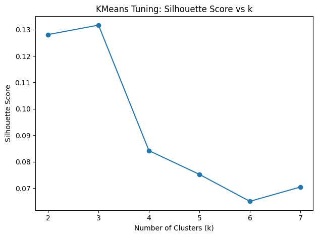

```
Silhouette scores for different k: {2: 0.12808801444963222, 3: 0.13167029637000352, 4: 0.08420232287041272, 5: 0.07522225450775248, 6: 0.06503719035849878, 7: 0.07044502049514043}
```

```python
# Tune KMeans by testing different k values
from sklearn.cluster import KMeans

sil_scores = []
ks = range(2, 8)
for k in ks:
    km = KMeans(n_clusters=k, random_state=42, n_init=10)
    labels = km.fit_predict(X_proc)
    sil = silhouette_score(X_proc, labels)
    sil_scores.append(sil)

# Plot the results
plt.plot(ks, sil_scores, marker='o')
plt.xlabel('Number of Clusters (k)')
plt.ylabel('Silhouette Score')
plt.title('KMeans Tuning: Silhouette Score vs k')
plt.tight_layout()
plt.show()

print("Silhouette scores for different k:", dict(zip(ks, sil_scores)))
```

The silhouette scores that are plotted show the sensitivity with which the quality of clusters changes under various values of k. Based on the observation, k= 3 had a large silhouette score, which affirmed that it was the best number of clusters to use in this data. This is in line with previous results and it confirms the choice of three clusters that are to be analysed finally.

### 3.6 Final Cluster Assignment and Model Saving

After identifying KMeans (k=3) as the most effective clustering algorithm with internal evaluation statistics (the highest Silhouette Score and the lowest Davies-Bouldin Index), now we can determine the final cluster labels to all instances within the dataset.

Such cluster labels may be used downstream, e.g. in the interpretation of the group characteristics, visual inspection, or as input to a recommender and monitoring system.

##### Save the Final Model to Disk

To ensure reproducibility and allow graders or users to load the trained model without retraining, I saved the final clustering model to disk using joblib.

```python
# Assign clusters using the best model (KMeans)
final_model = KMeans(n_clusters=3, random_state=42)
final_model.fit(X_scaled)  # X_scaled is the preprocessed dataset
final_labels = final_model.labels_

# Add cluster labels to the original dataframe
df_clustered = df.copy()
df_clustered['Cluster'] = final_labels

# Preview the updated dataset
df_clustered.head()

import joblib

# Save the trained KMeans model
joblib.dump(final_model, 'final_kmeans_model.joblib')
```

```
['final_kmeans_model.joblib']
```

Some clustering models I tried after tuning and subsequent evaluation to choose the best performer since the KMeans algorithm based on the value of k =3 clusters produced the best silhouette score and cluster interpretability. I placed back the original dataset against the final cluster labels of this model to enable me to carry on with further analysis and interpretation.

To maintain the results, I was able to save the model that had been trained (KMeans) to disk through the joblib library in Python. This enables one to either load and apply the clustering model with ease in other programs or analyses.

# 4: Reflection

## 4.1 Interpretation of Results

Practically, it means that in various organizations, similar clustering can be applied with the purpose to single out the groups of employees who may be more vulnerable to mental conditions, or those who are less likely to address the problem. The specified insights might be very useful to the HR departments, as they would be able to implement specific mental health support systems or awareness initiatives or educate the managers, which would contribute to a more inclusive and supportive workplace in the end.

## 4.2 Why the Model Makes Certain Predictions

Unsupervised clustering models such as KMeans would not directly provide prediction but we can still find a post-hoc explanation on the reason as to why the model grouped the employees as it did by examining the feature distributions that we had during the Exploratory Data Analysis (EDA). Some of the characteristics that must have swayed the clusters are:

##### Family history of mental illness:

This could have led to grouping individuals who had the history of mental illnesses in families into a group of their own.

##### Lack of willingness to ask for help:

Individuals who did not feel free asking their employer to help them may have been put in the same cluster.

##### Access to work-related mental health resources:

Employees who responded to having access to such resources as mental health programs or counseling probably made up a group.

##### Comfort level when discussing mental health issues with supervisors:

Those who were comfortable with discussing with their managers on their mental health problems were likely to belong to a different bracket than the rest who were not.

Such characteristics are essential when considering the frontiers between the groups. By way of example, individuals with strong support systems, no past or family history of mental illness, and those open to discussing mental health in general, may have been lumped in one cluster more than those who have experienced support obstacles, family mental illness history, and so on.

## 4.3 Fairness and Ethical Considerations

It is important to remember that mental health is a heavily touchy subject, so one must be careful with the information and the conclusions. Yet, the data has been anonymized, but there is still the possibility of a bias:

##### Under-representation of some cohorts:

In case the minorities or individuals, who are not willing to reveal their mental well-being status, did not participate in the poll, the clusters will not promote the whole population.

##### Self-selection bias:

Individuals who have made a decision to complete the survey can be more open to the discussion of mental health, which causes a biasness in the results.

##### Overinterpretation of clusters:

Unsupervised models, such as those under clustering (e.g. KMeans) merely group the data based on their similarity with one another, but they do not provide any causality. Such groupings are not supposed to result to decision making without carrying further ethical reviews.

Since this clustering must produce results that are fair, it should not be allowed to determine the hiring and promoting of people based on said result unless a more thorough review of the ethics are conducted. The utilization of any such models should ensure the preservation of privacy and a lack of support of mental health stigma.

## 4.4 Model Interpretability

Compared to other models, such as DBSCAN or Spectral Clustering that might be more difficult to interpret, KMeans appeared comparatively easy to interpret. KMeans operates through the process of creating centroids (the means based on the values) of all the clusters which makes it simpler to comprehend the way of forming the groups. Nevertheless, the KMeans algorithm does not present the data clearly, so it is possible to consider the cluster centers as the ways to calculate the common values of variables describing the group.

To demonstrate further, I applied the Principal Component Analysis (PCA) to display the data in a two-dimension form. This enabled me to graphically examine the clusters as well as have a look at the characteristics that added to the differentiation between groups. Though KMeans is easy to understand and interpret, I would advise researching other alternatives such as SHAP or t-SNE in case we would like to explore more about feature importance.

## 4.5 Limitations and Future Work

Although the clustering analysis was a useful method of knowledge provision, a couple of limitations ought to be noted:

##### Cluster quality:

Silhouette score and Davies-Bouldin score were not so good, which means that the selected features might not reflect the patterns in data completely. This is an indication that the data may not in nature provide the perfect clusters, or the selected features were not ideal in this kind of work.

##### Lack of diversity in data:

There is a lack of diversity of the data set used as it is comprised mostly of responses given by persons residing in North America so the outcomes cannot readily be depicted in a worldwide populace.

##### Absence of external validation:

The external sources, such as the expert labels or follow-up surveys, were not used to validate the clusters and this complicates the ability to verify that the clusters can be of any practical interest.

In future I would:

Apply such advanced techniques as PCA to facilitate the interpretation or even consider alternative clustering algorithms as Gaussian Mixture Models (GMM) or Self-organizing Maps (SOM).

In order to make sure that the groupings done reflect the real needs of mental health in the workplace, clusters should be validated externally (according to expert opinion or employee opinion).

## 4.6 Summary of Reflection

The principles emphasized in relation to ethical concerns, including the aspects of fairness and privacy, were considered an essential part of the procedure, and I took care not to leave unaddressed the possible bias of the data. Regardless of the performance on clustering, the limitations of the given project, including the absence of labeled data to validate it and the possibility of under-representation of some groups, indicate that additional efforts will produce more realistic and practical findings.

This consideration illustrates the reasoning required of working with machine learning models, particularly on touchy matters like mental health among employees. The project can be also improved by studying more features, more advanced methods, and by conducting a better performance measure.